# Assignment week 2

##### Assignment question 9:

Using this output, answer the following:

1. Where there any differences? (we will discuss this on Wednesday)
2. What is the estimated mean for infected individuals? Calculate it using only the coefficients!

We are not focusing yet on assumptions. But usually, we can check most of them by running:

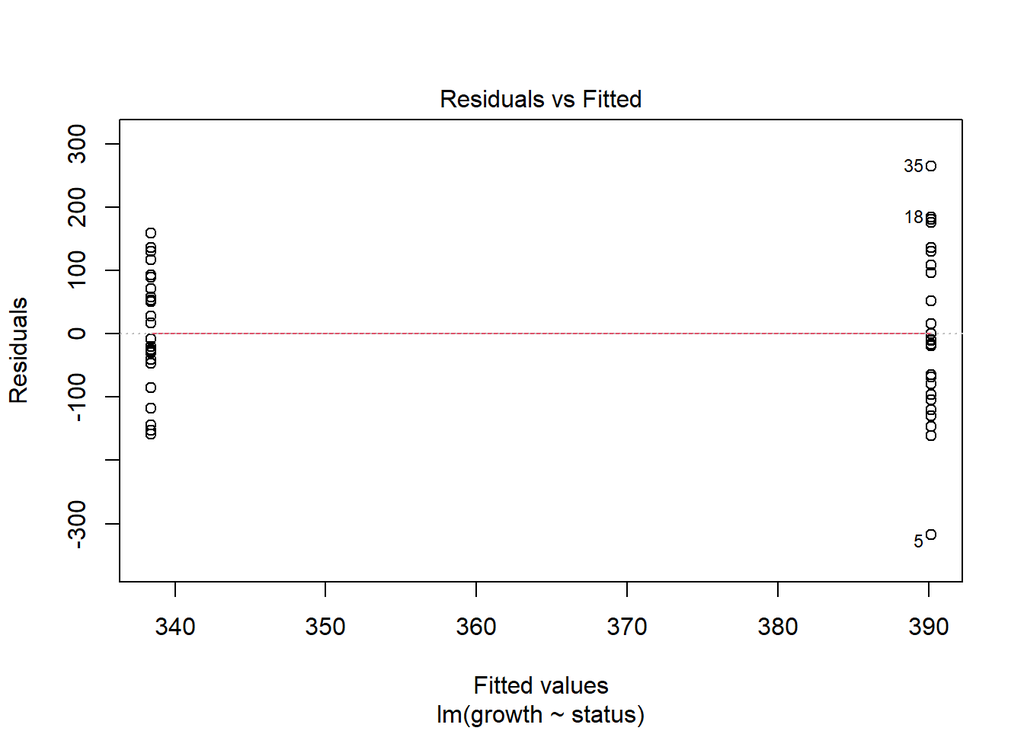

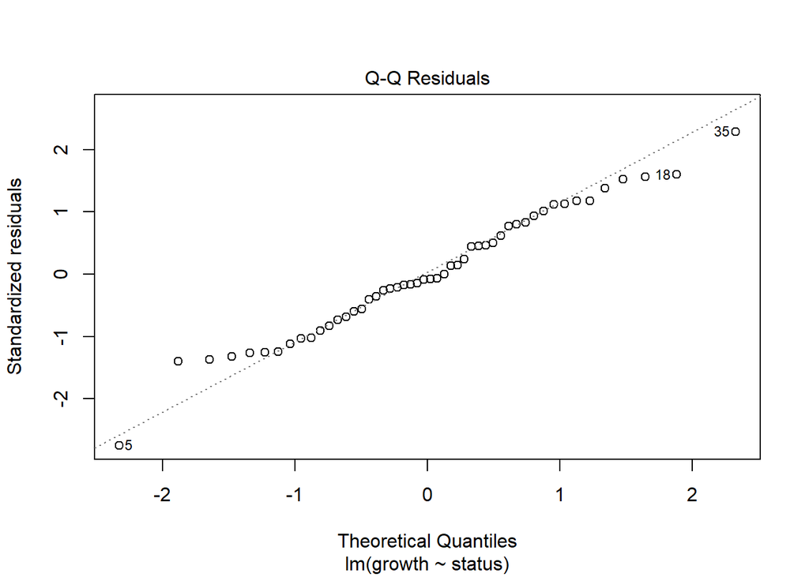

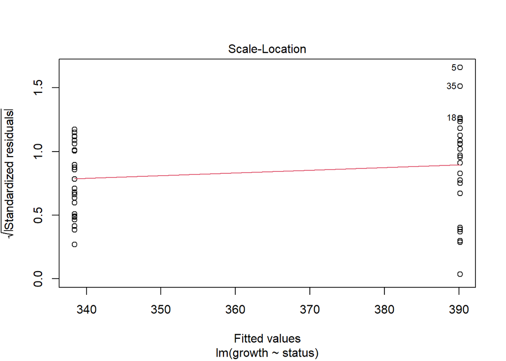

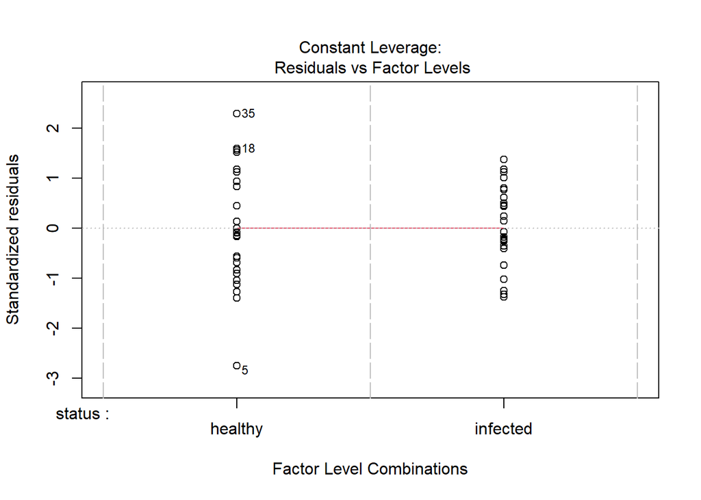

```r
plot(model2)
```

In this case they look good.

Finally, to run a 2-sample t-test we need to know whether the variance is equal. Do the following to test it:

```r
yH <- tunadata$growth[tunadata$status== 'healthy']
yI <- tunadata$growth[tunadata$status== 'infected']
```

```r
var.test(yH,yI)
```

```
    F test to compare two variances

data:  yH and yI
F = 1.9821, num df = 24, denom df = 24, p-value = 0.1004
alternative hypothesis: true ratio of variances is not equal to 1
95 percent confidence interval:
 0.8734287 4.4978255
sample estimates:
ratio of variances
          1.982052
```

Are the variances equal? or not? Remember, **usually** a p value lower than 0.05 means difference.

Also, read the alternative hypotehsis: `true ratio of variances is not equal to 1` check the 95% confidence interval, does it include 1?

Finally, let’s run the t-test. This code chunk is incomplete. You have to specify whether the variance is equal or not. Use the results from the variance test to make your decision.

```r
t.test(growth ~ status, data = tunadata,
       var.equal = , paired = FALSE,
       alternative = )
```

**✏️ Question 6 ✏️**

1. Download the teporingos2pops.csv file, run a linear model on it and plot a boxplot with points of different color. For fun, try to also have the boxplot be a different color. IT doesn’t have to look good, just explore and play with ggplot.
2. Describe what a boxplot is. We will talk more about it during our “plotting and visualizing” classes, but if you don’t know what it is, this is a good time to research it and try to describe it

## Supplementary information. For loops and a “challenge”

This is not a part of the assignment, but it is a useful guide. There is also a cool challengfe at the end if you want to attempt it.

For loops aren’t the only kind of loops. If you remember, the for loops looked like this (see this section on html or a fully rendered document):

```
flowchart LR
  A[Initialization] --> B(Code Block)
  B --> C{Lasit Iteration?}
  C --> |YES|D[End]
  C --> |NO|A
```

There are other types of loops

For example, a while-loop is:

```
flowchart LR
  A[Logical Condition] -->|True|B(Code Block)
  B --> A
  A --> |False|C[End]
```

And a repeat loop is:

```
flowchart LR
  A(Code Block) -->B(Logical Condition)
  B --> |False|A
  B --> |True|C[End]
```

Some of the important functions to know.

- `for` iterates over a sequence
- `while` executes a set of statement as long as a logical condition is true
- `break` stops the loop before it loops through all items
- `next` skip to next iteration before terminating the code chunk
- `if...else` might also be good to know to set logical conditions

#### Challenge

You are going to flip a **fair** coin 10,000,000 times. However, if you get lucky and get 20 **straight** tails, you get to stop flipping a coin (and you get 10 extra credit points!) You need the record in which throw you got the 20th straight tail, and print it. If you are able to do all of this, you get the credits! Bonus credits if your code is shorter than mine :)